# Case Study IV

Emily Schmidt and Genta Mehmeti

2023-05-31

# 1 Background

Due to your education at the Geneva School of Economics and Management you are aware of the potential of conjoint studies to support this type of management decision problems. Luckily you can convince your new boss to conduct a research project with a research agency. Based on the result of the conjoint study you have already built a conjoint simulator.

Please use the conjoint simulator, that you have created based on the provided skeleton, in order to answer several questions related to management decisions concerning the introduction of the new Xiaomi smartphone. You will have to simulate different scenarios to arrive at a solution for the decision problems. You can vary your phone on five different attributes namely: price, screen, sound, sim-card , as well as camera. Below you find a table with five attributes and the different attribute levels.

For the calculation of revenues and profits assume for simplicity, that the market volume is 10 million smartphones in the EMEA-region. In general, conduct your simulations for first choice and logit-rules, but base your decisions on the result of the logit-rule.

## 1.1 Load Libraries

```r
library(ggplot2)
library(dplyr)
library(patchwork)

require(gridExtra)
```

## 1.2 Clear Enviroment

```r
# Clear the environment and console
rm(list=ls())
graphics.off()
#shell("cls")
```

# 2 Question 1

Suppose your new Xiaomi smartphone would be launched with the lowest attribute levels on the four non-price attributes, e.g. Screen = LED, Sound = Mono, etc. Your boss thinks that a price of 350$ would be reasonable for such a product, as you would be the cheapest competitor in the market.

- *What will be preference share that this product will attain with First-Choice and Logit in EMEA market?*

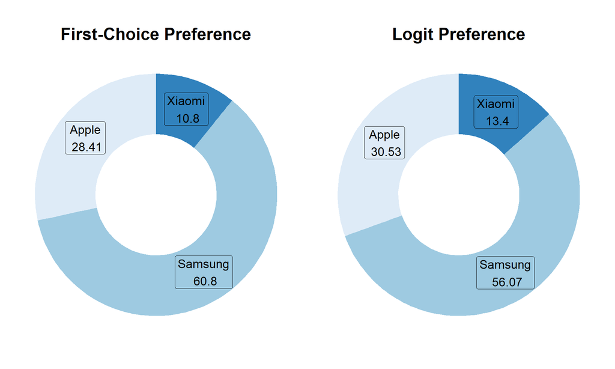

As we learned in class, the first-choice model focuses on the respondent’s initial selection, offering some insights into the attributes that influence initial preferences. In our case, this would reveal the primary considerations (in percentage) that influence customers’ decisions to purchase Xiaomi products. Moreover, using the observed or measured attributes and their corresponding utilities, the Logit Model calculates the likelihood of selecting a specific option among a set of alternatives. The logit function will convert the utilities into choice probabilities under the assumption that the choice probabilities follow a particular mathematical function as seen in class (Slide: Modeling Choice - Choice between alternatives).This approach, also referred to as the multinomial logit model, is based on the ideas of discrete choice theory and makes the assumption that consumers make decisions based on the utility or preference they give to each available option. We will use Logit because our main goals are to comprehend overall choice behavior and assess the relative importance of various attributes.

Recently, a new Xiaomi smartphone was introduced to the EMEA market, which has the lowest price compared to its competitors, Apple and Samsung. In one of the non-price attributes though, the novel product has the lowest level of screen and sound type while the competition has either a level two or three. The other attributes for the camera and sim card remain the same for all devices. From analyzing the preference market share attained with First-Choice and Logit, it is clear that Samsung’s smartphone dominates in either situation (60.80% and 56.07%). Unfortunately, Xiaomi is lower than Apple too. Overall, our new phone has a slightly better Logit percentage than in First-Choice. Throughout this analysis, simulations will be based on both preference shares, but decisions will be driven through Logit. Within the mathematical framework the $P(k|K)$ for Xiaomi is 13.4% by taking into consideration the utilities (screen and sound type) dividing by the sum of utilities (screen and sound type) for all the products (Xiamo, Samsung and Apple.).

- *How would you change the price to increase revenues?* There are four levels for price, $300, $350, $400, and $450. Since the first simulation had a level two price at $350, we now analyze how price and preference share relate. The bar plot depicts the story well, demonstrating that if price decreases to $300, then market share will increase from 13.40% to 18.22%. If though the opposite happens and price is increased, market share drops to 6.66% and 3.62% respectively. Therefore, we would suggest that for this specific Xiaomi smartphone, changing the price to a lower value will attract more consumers, driving a higher revenue.

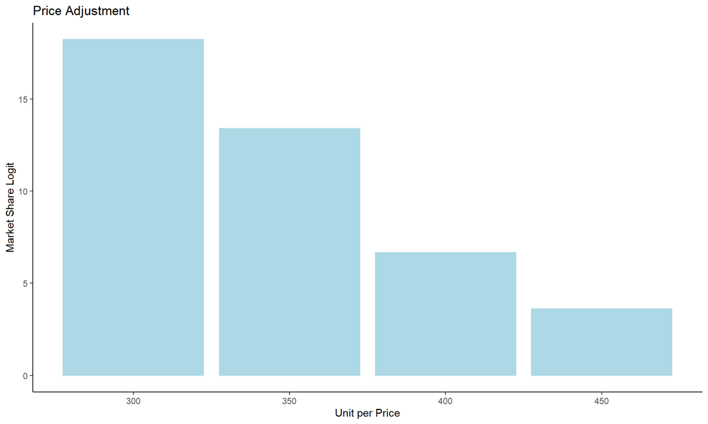

```r
df <- data.frame(price = c(300, 350, 400, 450),
                percentage = c(18.22, 13.40, 6.66, 3.62))

ggplot(data = df, aes(x = price, y = percentage)) +
  geom_bar(stat = "identity", color = "lightblue", fill = "lightblue") +
  xlab("Unit per Price") +
  ylab("Market Share Logit") +
  ggtitle("Price Adjustment") + theme(plot.title = element_text(size = 20, face = "bold", hjust = 0.5)) +
  theme_classic()
```

- *By how much will your revenues change?*

# 3 Question 2

Assuming if you could improve only one attribute level by one unit (i.e. from Screen = LED to Screen = QLED), *which attribute would you choose to maximize your revenues assuming that the price is fixed at 350$*?

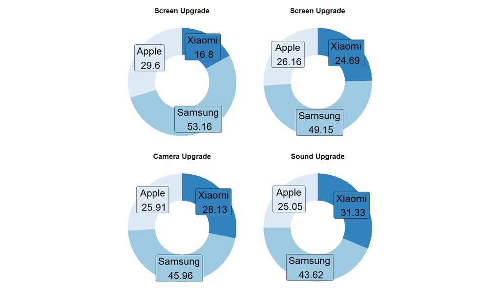

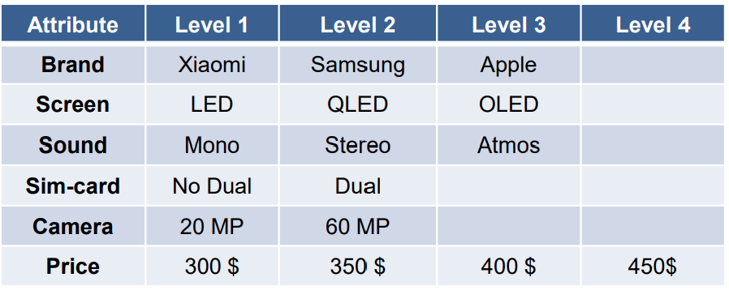

In conjoint analysis, various attribute levels are used to represent the various options or features of brands. Each attribute level affects customer preferences and, as a result, it will affect revenues differently. *Question 2* is asking which change in an attribute level would result in the greatest increase in revenue, assuming that only one attribute level can be improved by one unit. To answer this question, we have analyzed the price sensitivity associated with each attribute level. We evaluated how changes in attribute levels may impact customer willingness to pay at a fixed price point of $350.

Xiaomi has been given the opportunity to potentially improve a attribute level by one unit. To identify which attribute would be most advantageous in terms of maximizing revenue, assuming price is fixed at $350, we ran several simulations. The four simulations changed only one attribute level while all else stayed constant. For instance, lets analyze screen. If Xiaomi decided to update screen from `LED` to `QLED`, the preference share actually slightly decreases to 16.80% from their optimal share at $300, but increases by a lot if considering their original share of 13.40% in terms of the Logit share. As we analyze each attribute, the preference share continues to increase. Most notably, sound appears to bring in the most share as it is higher than all other upgrades at 31.33%. It is highly recommended that if Xiaomi was set on a price of $350, they should upgrade the sound from `Mono` to `Stereo`.

# 4 Question 3

Assuming your R&D department gives you the opportunity to change the screen and the sound. The following table shows you by how much the manufacturing cost per unit will increase for different attribute improvements.

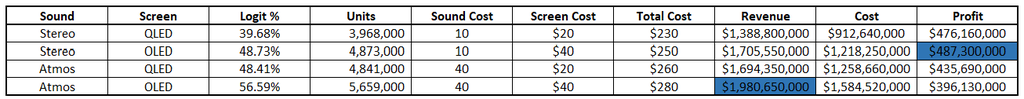

The information about manufacturing cost per unit varies for different attribute improvements that is relevant for analyzing the trade-offs between cost and potential revenue impact. In the context of conjoint analysis, the choices and decisions customers make when presented with alternatives that differ in their attributes or features are referred as trade-offs. In addition, managers make trade-off decisions based on the customer preferences and priorities after weighing the costs and benefits of various attribute levels. Therefore, we will see how the change in screen and sound will affect our manufacturing costs.

- *What product will you launch to maximize revenues?*  
  Research and Development has given us the opportunity to change both the screen and sound attributes. As previously seen, preference market share was highest in sound, and we can make the assumption that the optimal product for consumers will have the highest level of sound. To ensure that all combinations of screen and sound were tested, we developed a Excel spreadsheet to compute our calculations. We have assumed that price continues to be constant at $350. In total, there were four combinations tested and once those were inputted into the conjoint simulator, we acquired the preference market share for Logit. From there, the Logit percentage was multiplied by the 10 million units for each combination. The additional sound and screen costs were inputted to be then added to the current base cost of $200 since these features were upgraded. The last three columns help to answer the two questions about revenue and profit.

To obtain the maximum revenue, the higher the market share, the more money Xiaomi can bring through their doors with this new smartphone. Therefore, if the company decides to not consider how much this would cost to build, the optimal choice would be to upgrade the screen from `LED` to `OLED` and the sound from the first level, `Mono`, to the highest, `Atmos`. The Logit market share is 56.59%, which is significantly higher if we had kept all non-price attributes the same. Even though this brings in $1,980,650,000, there is a high cost associated with creating this device.

# 5 Question 4

From a press release, you learn that your competitor Apple will deliver an improved version of its current smartphone at the same price beginning of the next month. The new version has a 60 MP camera. Assume your competitor Samsung will reduce its price by 50$ as a reaction to this new Apple smartphone.

*If you could change only one attribute of your base smartphone which one would it be to maximize your profit in this new market situation*?

Conjoint analysis typically entails measuring respondents’ preferences and trade-offs after systematically presenting them with various product profiles that differ in attribute levels. For the purpose of informing decisions about product design, pricing, and market strategy, it aims to estimate attribute importance and utility values. However, in this question, we will choose one attribute that will change in our base smartphone, in order to increase profits in response to a competitor’s actions. This question is more aligned with strategic decision-making and competitive analysis rather than conjoint analysis, even though it is part of it. It involves considering market dynamics, competitor actions, and pricing strategies in a real-world context.

To make an informed decision in this scenario, we will consider various scenarios such as changes in screen, sound, sim card, and camera. It is crucial to conduct competitor analysis, and financial evaluations to determine the attribute change that would best position our smartphone for maximizing profits in response to the competitive landscape.

Therefore, without any of the new modifications proposed by Apple or Samsung, the table below shows the attributes and initial Logit preference share for each brand. Samsung has the highest share percentage, while Apple and Xiamoi are second and third in the market. The blue values highlight those that the competitors are targeting to change.

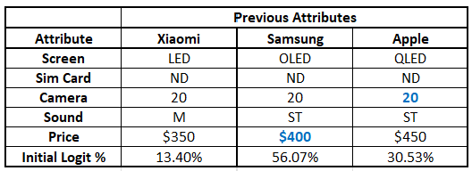

[figure not shown]

Xiaomi conducted six trials to test which smartphone configuration would be the optimal choice to maximize profit. Out of those choices, it appeared that only changing sound from `Mono` to `Atmos` had the most benefits as the preference share was the highest at 22.11%, resulting in the largest revenue and profit. In *Question 3*, the best combination for sound and screen included the `Atmos`, but the issue there was that the level of attribute was too costly to include with the smartphone. Therefore, it did not give the best profit. Now that we are only picking one attribute, improving the sound system seems to be the attribute to upgrade since it brings in a profit of $243,210,000 compared to the other attributes.

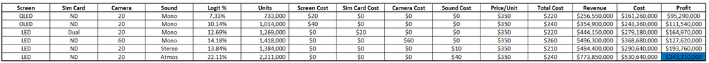